# Harsh_Singh_Youtube_EDA

Python Project 03

Exploratory Data Analysis on YouTube data.

```python
#import necessary libraries
import pandas as pd   #For data analysis and manupulation
import numpy as np    #For mathmatical operations
import matplotlib.pyplot as plt #For Graph
import seaborn as sns #For Graph
import calendar # For datetime
```

```python
def read_csv(file_loc,file_name):#Function to read csv file
 try:
  dataframe=pd.read_csv(file_loc+"/"+file_name)
  print("File read successfully...")
 except Exception as err:
  print(err)
 return dataframe
```

```python
df=read_csv(file_loc="D:/Python/Project_Work",file_name="youtube_dislike_dataset.csv")
```

```
File read successfully...
```

```python
#Display record
df.head()
```

|  | video_id | title | channel_id | channel_title | published_at | view_count | likes | dislikes | comment_count | tags | description | comments |
| --- | --- | --- | --- | --- | --- | --- | --- | --- | --- | --- | --- | --- |
| 0 | --0bCF-iK2E | Jadon Sancho Magical Skills & Goals | UC6UL29enLNe4mqwTfAyeNuw | Bundesliga | 2021-07-01 10:00:00 | 1048888 | 19515 | 226 | 1319 | football soccer ftbol alemn Bundesliga season ... | Enjoy the best skills and goals from Jadon San... | Respect to Dortmund fans,must be sad losing hi... |
| 1 | --14w5SOEUs | Migos - Avalanche (Official Video) | UCGIelM2Dj3zza3xyV3pL3WQ | MigosVEVO | 2021-06-10 16:00:00 | 15352638 | 359277 | 7479 | 18729 | Migos Avalanche Quality Control Music/Motown R... | Watch the the official video for Migos - "Aval... | Migos just makes me want to live my live to th... |
| 2 | --40TEbZ9Is | Supporting Actress in a Comedy: 73rd Emmys | UClBKH8yZRcM4AsRjDVEdjMg | Television Academy | 2021-09-20 01:03:32 | 925281 | 11212 | 401 | 831 |  | Hannah Waddingham wins the Emmy for Supporting... | Hannah's energy bursts through any screen. Wel... |
| 3 | --4tfbSyYDE | JO1'YOUNG (JO1 ver.)' PERFORMANCE VIDEO | UCsmXiDP8S40uBeJYxvyulmA | JO1 | 2021-03-03 10:00:17 | 2641597 | 39131 | 441 | 3745 | PRODUCE101JAPAN JO1 TheSTAR STA... | JO1'YOUNG (JO1 ver.)' PERFORMANCE VIDEO\n\n---... | youngVer>< REN is really PERFECT. It's not ju... |
| 4 | --DKkzWVh-E | Why Retaining Walls Collapse | UCMOqf8ab-42UUQIdVoKwjlQ | Practical Engineering | 2021-12-07 13:00:00 | 715724 | 32887 | 367 | 1067 | retaining wall New Jersey highway Direct Conne... | One of the most important (and innocuous) part... | Keep up with all my projects here: https://pr... |

```python
# Columns Present in data
df.columns,len(df.columns)
```

```
(Index(['video_id', 'title', 'channel_id', 'channel_title', 'published_at',
        'view_count', 'likes', 'dislikes', 'comment_count', 'tags',
        'description', 'comments'],
       dtype='object'),
 12)
```

### 1. Import required libraries and read the provided dataset (youtube_dislike_dataset.csv) and retrieve top 5 and bottom 5 records.

```python
# Display upper Five rows
df.head(5)
```

|  | video_id | title | channel_id | channel_title | published_at | view_count | likes | dislikes | comment_count | tags | description | comments |
| --- | --- | --- | --- | --- | --- | --- | --- | --- | --- | --- | --- | --- |
| 0 | --0bCF-iK2E | Jadon Sancho Magical Skills & Goals | UC6UL29enLNe4mqwTfAyeNuw | Bundesliga | 2021-07-01 10:00:00 | 1048888 | 19515 | 226 | 1319 | football soccer ftbol alemn Bundesliga season ... | Enjoy the best skills and goals from Jadon San... | Respect to Dortmund fans,must be sad losing hi... |
| 1 | --14w5SOEUs | Migos - Avalanche (Official Video) | UCGIelM2Dj3zza3xyV3pL3WQ | MigosVEVO | 2021-06-10 16:00:00 | 15352638 | 359277 | 7479 | 18729 | Migos Avalanche Quality Control Music/Motown R... | Watch the the official video for Migos - "Aval... | Migos just makes me want to live my live to th... |
| 2 | --40TEbZ9Is | Supporting Actress in a Comedy: 73rd Emmys | UClBKH8yZRcM4AsRjDVEdjMg | Television Academy | 2021-09-20 01:03:32 | 925281 | 11212 | 401 | 831 |  | Hannah Waddingham wins the Emmy for Supporting... | Hannah's energy bursts through any screen. Wel... |
| 3 | --4tfbSyYDE | JO1'YOUNG (JO1 ver.)' PERFORMANCE VIDEO | UCsmXiDP8S40uBeJYxvyulmA | JO1 | 2021-03-03 10:00:17 | 2641597 | 39131 | 441 | 3745 | PRODUCE101JAPAN JO1 TheSTAR STA... | JO1'YOUNG (JO1 ver.)' PERFORMANCE VIDEO\n\n---... | youngVer>< REN is really PERFECT. It's not ju... |
| 4 | --DKkzWVh-E | Why Retaining Walls Collapse | UCMOqf8ab-42UUQIdVoKwjlQ | Practical Engineering | 2021-12-07 13:00:00 | 715724 | 32887 | 367 | 1067 | retaining wall New Jersey highway Direct Conne... | One of the most important (and innocuous) part... | Keep up with all my projects here: https://pr... |

```python
# Display Lower Five rows
df.tail(5)
```

|  | video_id | title | channel_id | channel_title | published_at | view_count | likes | dislikes | comment_count | tags | description | comments |
| --- | --- | --- | --- | --- | --- | --- | --- | --- | --- | --- | --- | --- |
| 37417 | zzd4ydafGR0 | Lil Tjay - Calling My Phone (feat. 6LACK) [Off... | UCEB4a5o_6KfjxHwNMnmj54Q | Lil Tjay | 2021-02-12 05:03:49 | 120408275 | 2180780 | 35871 | 81360 | Lil Tjay Steady Calling My Phone Calling My Ph... | Official video for "Calling My Phone" by Lil T... | 'DESTINED 2 WIN' OUT NOW !! https://liltjay.ln... |
| 37418 | zziBybeSAtw | PELICANS at LAKERS \| FULL GAME HIGHLIGHTS \| Ja... | UCWJ2lWNubArHWmf3FIHbfcQ | NBA | 2021-01-16 05:39:05 | 2841917 | 20759 | 1049 | 2624 | NBA G League Basketball game-0022000187 Lakers... | PELICANS at LAKERS \| FULL GAME HIGHLIGHTS \| Ja... | Montrezl Harrell is going crazy with the rebou... |
| 37419 | zzk09ESX7e0 | [MV] (MAMAMOO) - Where Are We Now | UCuhAUMLzJxlP1W7mEk0_6lA | MAMAMOO | 2021-06-02 09:00:10 | 13346678 | 720854 | 4426 | 90616 | MAMAMOO WAW WAW MAMAMOO WAW Where Are We Now... | [MV] (MAMAMOO) - Where Are We Now\n\nInstagra... | I honestly do not know why this song hit so ha... |
| 37420 | zzmQEb0Em5I | FELLIPE ESCUDERO- Master Podcast #12 | UC8NjnNWMsRqq11NYvHAQb1g | Master Podcast | 2020-10-20 20:59:30 | 252057 | 19198 | 1234 | 1471 | master masterpodcast lord lord vinheteiro z z ... | DOCTOR HAIR\nhttps://www.thedoctorhair.com/?fb... | Foi um prazer passar esta tarde com vocs debat... |
| 37421 | zzxPZwaA-8w | Gareth Bale brace secures dramatic comeback on... | UCEg25rdRZXg32iwai6N6l0w | Tottenham Hotspur | 2021-05-23 21:00:31 | 2252090 | 34063 | 868 | 2004 | Spurs Tottenham Hotspur Tottenham Leicester ... | Two minute highlights from Tottenham Hotspur's... | Thank you Kane for everything you have given t... |

### 2. Check the info of the dataframe and write your inferences on data types and shape of the dataset.

```python
df.info() # Show Informatation about data
```

```
<class 'pandas.core.frame.DataFrame'>
RangeIndex: 37422 entries, 0 to 37421
Data columns (total 12 columns):
 #   Column         Non-Null Count  Dtype
---  ------         --------------  -----
 0   video_id       37422 non-null  object
 1   title          37422 non-null  object
 2   channel_id     37422 non-null  object
 3   channel_title  37422 non-null  object
 4   published_at   37422 non-null  object
 5   view_count     37422 non-null  int64
 6   likes          37422 non-null  int64
 7   dislikes       37422 non-null  int64
 8   comment_count  37422 non-null  int64
 9   tags           37422 non-null  object
 10  description    37422 non-null  object
 11  comments       37264 non-null  object
dtypes: int64(4), object(8)
memory usage: 3.4+ MB
```

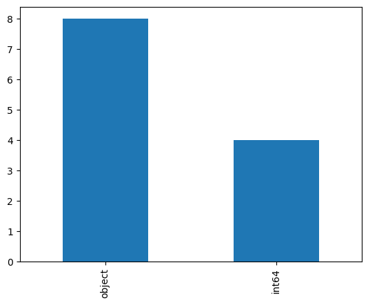

```python
df.dtypes.value_counts().plot(kind="bar")
plt.show()
```

1. Datatypes: Out of the 12 columns in the dataset:

=> 8 columns have an object datatype.

=> 4 columns have an integer datatype.

2. Shape: The dataset consists of 37,422 rows and 12 columns.

### 3. Check for the Percentage of the missing values and drop or impute them.

```python
def missing_value(data):#Function to show missing value columns
    null=data.isnull().sum()
    null=round((null / len(data)) * 100, 2)
    return null
```

```python
missing_value(df)#Show missing values in %
```

```
video_id         0.00
title            0.00
channel_id       0.00
channel_title    0.00
published_at     0.00
view_count       0.00
likes            0.00
dislikes         0.00
comment_count    0.00
tags             0.00
description      0.00
comments         0.42
dtype: float64
```

=>All columns, except the "comments" column, have no missing values.

=>Missing values are droped becouse it has object data types and missing value less than 1%

```python
def drop(data):#Function to drop missing value
 data.dropna(inplace=True)
 print(f"Missing values are droped...")
 return data
```

```python
df=drop(df,)#Drop Missing Values
```

```
Missing values are droped...
```

```python
missing_value(df)#Checking missing values
```

```
video_id         0.0
title            0.0
channel_id       0.0
channel_title    0.0
published_at     0.0
view_count       0.0
likes            0.0
dislikes         0.0
comment_count    0.0
tags             0.0
description      0.0
comments         0.0
dtype: float64
```

### 4. Check the statistical summary of both numerical and categorical columns and write your inferences.

```python
round(df.describe(include=np.number),2)# Summary of numerical data
```

|  | view_count | likes | dislikes | comment_count |
| --- | --- | --- | --- | --- |
| count | 3.726400e+04 | 37264.00 | 37264.00 | 37264.00 |
| mean | 5.710821e+06 | 167286.70 | 4996.43 | 9966.95 |
| std | 2.431304e+07 | 538493.10 | 30751.94 | 117346.47 |
| min | 2.036800e+04 | 22.00 | 3.00 | 1.00 |
| 25% | 5.141305e+05 | 13317.25 | 282.75 | 914.00 |
| 50% | 1.321860e+06 | 42556.00 | 798.00 | 2347.00 |
| 75% | 3.674527e+06 | 130966.50 | 2466.25 | 6212.00 |
| max | 1.322797e+09 | 31837675.00 | 2397733.00 | 16071029.00 |

Inference:

1. The dataset contains information about 37,264 videos.

2. The view_count, likes, dislikes, and comment_count vary significantly from one video to another, as indicated by the large standard deviations.

3. The median values for view_count, likes, dislikes, and comment_count are generally much lower than their corresponding means, suggesting that a few highly popular videos with exceptionally high numbers of views, likes, dislikes, and comments might be skewing the means upwards.

4. The minimum values for all four attributes (view_count, likes, dislikes, and comment_count) are greater than zero, indicating that all videos in the dataset have at least some views, likes, dislikes, and comments.

5. The maximum values are extremely high for view_count, likes, dislikes, and comment_count, indicating that there are a few extremely popular videos in the dataset with very high engagement metrics.

```python
df.describe(include="object")# Summary of object data
```

|  | video_id | title | channel_id | channel_title | published_at | tags | description | comments |
| --- | --- | --- | --- | --- | --- | --- | --- | --- |
| count | 37264 | 37264 | 37264 | 37264 | 37264 | 37264 | 37264 | 37264 |
| unique | 37264 | 36958 | 10891 | 10813 | 36617 | 28705 | 35479 | 37264 |
| top | --0bCF-iK2E | www | UCNAf1k0yIjyGu3k9BwAg3lg | Sky Sports Football | 2020-10-16 04:00:10 |  |  | Respect to Dortmund fans,must be sad losing hi... |
| freq | 1 | 21 | 533 | 533 | 6 | 3808 | 587 | 1 |

Inference:

1. Some videos have the same title, channel_id, channel_title, tags, and description, suggesting that multiple videos might be related to the same content or belong to the same channel.

2. The most frequently occurring channel in the dataset is "Sky Sports Football," with 533 videos associated with it.

3. The dataset seems to have a wide variety of videos, as indicated by the high number of unique titles, channel IDs, channel titles, and published dates.

### 5. Convert datatype of column published_at from object to pandas datetime.

```python
def datetime_conveter(data,col):#Function to convert dtype in datetime formate
    data[col]=pd.to_datetime(df[col])
    print("Convert successfully in Datetime formate...")
    return data
```

```python
df=datetime_conveter(df,"published_at")# Convert the 'published_at' column to a datetime datatype.
```

```
Convert successfully in Datetime formate...
```

```python
df.info() # Checking datatype
```

```
<class 'pandas.core.frame.DataFrame'>
Int64Index: 37264 entries, 0 to 37421
Data columns (total 12 columns):
 #   Column         Non-Null Count  Dtype
---  ------         --------------  -----
 0   video_id       37264 non-null  object
 1   title          37264 non-null  object
 2   channel_id     37264 non-null  object
 3   channel_title  37264 non-null  object
 4   published_at   37264 non-null  datetime64[ns]
 5   view_count     37264 non-null  int64
 6   likes          37264 non-null  int64
 7   dislikes       37264 non-null  int64
 8   comment_count  37264 non-null  int64
 9   tags           37264 non-null  object
 10  description    37264 non-null  object
 11  comments       37264 non-null  object
dtypes: datetime64[ns](1), int64(4), object(7)
memory usage: 3.7+ MB
```

=>"published_at" column changed into datetime64[ns] datatype

### 6. Create a new column as "published_month" using the column published_at (display the months only)

```python
def extract_month(data,new_col,col):# Extract the month from the 'published_at' column and create a new column 'published_month'
    data[new_col]=data[col].dt.month
    print("Extraction successfully done...")
    print(pd.DataFrame(data[new_col].head()))
    return data
```

```python
df=extract_month(df,new_col="published_month",col="published_at" )#Calling Function
```

```
Extraction successfully done...
   published_month
0                7
1                6
2                9
3                3
4               12
```

```python
pd.DataFrame(df["published_month"])#Checking new column published_month
```

|  | published_month |
| --- | --- |
| 0 | 7 |
| 1 | 6 |
| 2 | 9 |
| 3 | 3 |
| 4 | 12 |
| ... | ... |
| 37417 | 2 |
| 37418 | 1 |
| 37419 | 6 |
| 37420 | 10 |
| 37421 | 5 |

37264 rows × 1 columns

=>Create new column df["published_month"] and assign the months from column df["published_at"] by using .dt.month

### 7. Replace the numbers in the column published_month as names of the months i,e., 1 as "Jan", 2 as "Feb"

and so on.....

```python
def month_name(data,col):# Function Convert month number into month name
    data[col]=data[col].apply(lambda x: calendar.month_name[x])
    print("Convert successfully...")
    print(pd.DataFrame(data[col].head()))
    return data
```

```python
df=month_name(df,col="published_month")
```

```
Convert successfully...
  published_month
0            July
1            June
2       September
3           March
4        December
```

```python
pd.DataFrame(df["published_month"])#Show changed in Column
```

|  | published_month |
| --- | --- |
| 0 | July |
| 1 | June |
| 2 | September |
| 3 | March |
| 4 | December |
| ... | ... |
| 37417 | February |
| 37418 | January |
| 37419 | June |
| 37420 | October |
| 37421 | May |

37264 rows × 1 columns

=>Month number changed into month name

### 8. Find the number of videos published each month and arrange the months in a decreasing order based

on the video count.

```python
pd.DataFrame(df["published_month"].value_counts(ascending=False))#Show video_count of each published_month in decending order
```

|  | published_month |
| --- | --- |
| October | 4976 |
| September | 4854 |
| November | 4821 |
| August | 4250 |
| December | 3063 |
| July | 2331 |
| June | 2305 |
| March | 2248 |
| February | 2125 |
| April | 2119 |
| January | 2099 |
| May | 2073 |

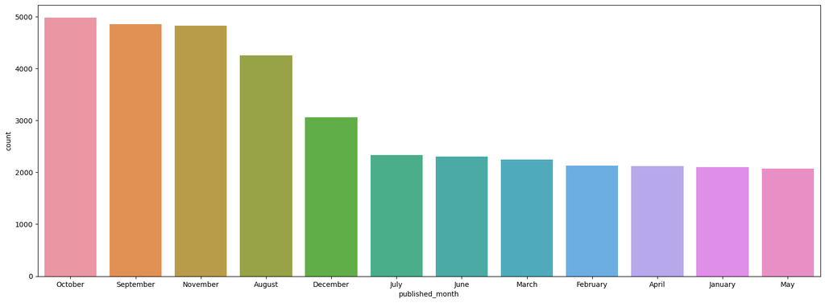

```python
plt.figure(figsize=(20,7))
sns.countplot(data=df,x="published_month",order=df["published_month"].value_counts(ascending=False).index)
plt.show()
```

### 9. Find the count of unique video_id, channel_id and channel_title.

```python
pd.DataFrame(df[["video_id","channel_id","channel_title"]].nunique())
```

|  | 0 |
| --- | --- |
| video_id | 37264 |
| channel_id | 10891 |
| channel_title | 10813 |

Inference :

1. Every video_id is unique.

2. Count of channel_id and channel_title is less than video_id(Some Channels has multiple videos)

### 10. Find the top10 channel names having the highest number of videos in the dataset and the bottom10 having lowest number of videos.

```python
# Top 10 channel_title with highest number of videos count
pd.DataFrame(df["channel_title"].value_counts(ascending=False)).head(10)
```

|  | channel_title |
| --- | --- |
| Sky Sports Football | 533 |
| The United Stand | 301 |
| BT Sport | 246 |
| NBA | 209 |
| NFL | 162 |
| WWE | 122 |
| SSSniperWolf | 99 |
| SSundee | 98 |
| FORMULA 1 | 87 |
| NHL | 86 |

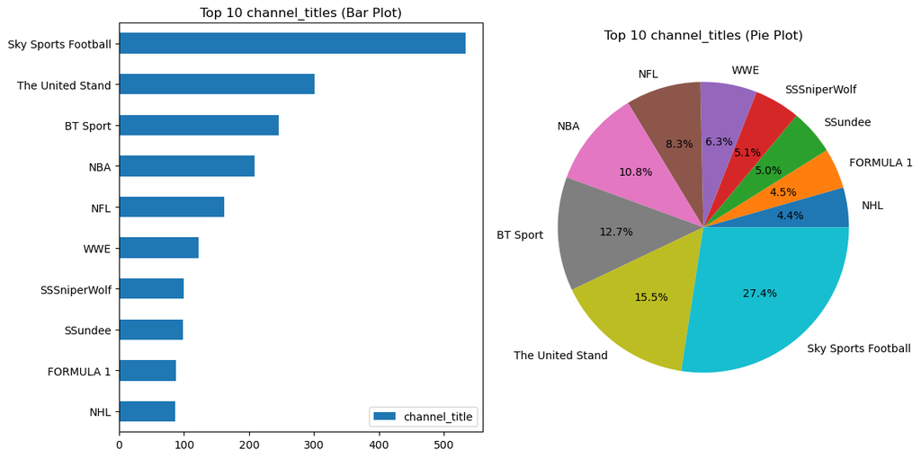

```python
df_counts=pd.DataFrame(df["channel_title"].value_counts(ascending=True)).tail(10)


fig, (ax1, ax2)=plt.subplots(1, 2, figsize=(12, 6))

df_counts.plot(kind="barh", ax=ax1)
ax1.set_title("Top 10 channel_titles (Bar Plot)")

zx=df_counts.values.flatten()
zy=df_counts.index
ax2.pie(zx, labels=zy, autopct="%1.1f%%")
ax2.set_title("Top 10 channel_titles (Pie Plot)")

plt.tight_layout()
plt.show()
```

Inference :

1. SkySky Sports Football has highest video_count 533 in top 10.

2. NHL has lowest video_counts 86 in top 10.

```python
# Top 10 channel_title with lowest number of videos count
pd.DataFrame(df["channel_title"].value_counts(ascending=True)).head(10)
```

|  | channel_title |
| --- | --- |
| Out of Focus | 1 |
| Ido | 1 |
| German *El Classico* | 1 |
| HowToMin - Minute Cooking Recipes | 1 |
| MBC Radio | 1 |
| Yama Q | 1 |
| melissa the groomer | 1 |
| No0b3 | 1 |
| Isamara Amncio | 1 |
| JustNova | 1 |

4. Bottom 10 channels has only 1 video_count

### 11. Find the title of the video which has the maximum number of likes and the title of the video having minimum likes and write your inferences.

```python
#Show channel title with Maximum number of likes
df[["title","likes"]].sort_values(by="likes",ascending=False).head(1)
```

|  | title | likes |
| --- | --- | --- |
| 26143 | BTS () 'Dynamite' Official MV | 31837675 |

```python
#Show channel title with Minimum number of likes
pd.DataFrame(df.groupby("title").max()["likes"]).sort_values(by="likes").head(1)
```

| title | likes |
| --- | --- |
| Leading the Charge \| Circle K | 22 |

Inference :

1. The video titled "BTS () "Dynamite" Official MV" has the highest number of likes, with a number 3,18,37,675 likes.

2. On the other hand, the video titled "Leading the Charge | Circle K" has the lowest number of likes, with only 22 likes.

### 12. Find the title of the video which has the maximum number of dislikes and the title of the video having minimum dislikes and write your inferences.

```python
#Show channel title with Maximum number of dislikes
pd.pivot_table(df,index="title",values="dislikes",aggfunc="max").sort_values(by="dislikes",ascending=False).head(1)
```

| title | dislikes |
| --- | --- |
| Cuties \| Official Trailer \| Netflix | 2397733 |

```python
#Show channel title with Minimum number of dislikes
pd.pivot_table(df,index="title",values="dislikes",aggfunc="min").sort_values(by="dislikes",ascending=False).tail(1)
```

| title | dislikes |
| --- | --- |
| Tims For Good: A Taste Of The Familiar | 3 |

Inference :

### 13. Does the number of views have any effect on how many people disliked the video? Support your answer with a metric and a plot.

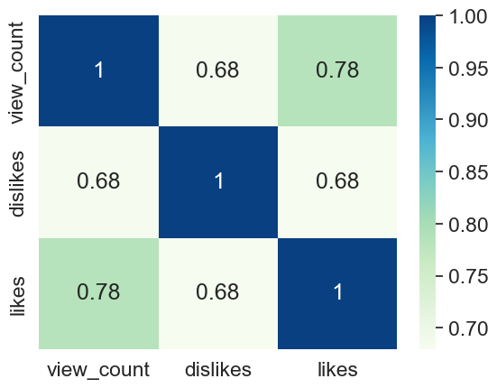

```python
# Show Correlation
sns.set(font_scale=1.5)
sns.heatmap(df[["view_count","dislikes","likes"]].corr(),annot=True,cmap="GnBu")
plt.show()
```

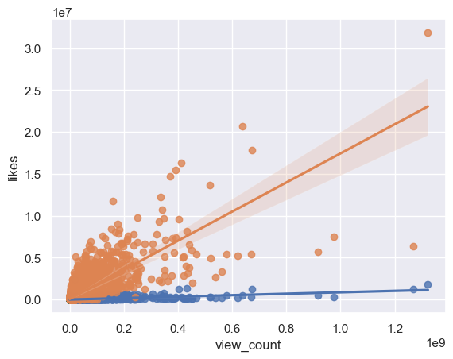

```python
sns.set(font_scale=1)#reglot likes and dislikes with view_count
sns.regplot(data=df,x="view_count",y="dislikes")
sns.regplot(data=df,x="view_count",y="likes")
plt.show()
```

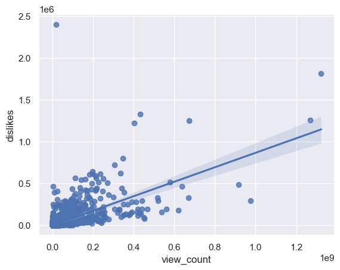

```python
sns.regplot(data=df,x="view_count",y="dislikes")#reglot dislikes with view_count
plt.show()
```

Inferences:

=>view_count has significant effect on liking/disliking the videos with the correlation of 0.78 and 0.68.This suggests that videos with higher view counts tend to receive more likes and dislikes.

### 14. Display all the information about the videos that were published in January, and mention the count of videos that were published in January.

```python
Jan=df[df["published_month"]=="January"]
Jan.head()
```

|  | video_id | title | channel_id | channel_title | published_at | view_count | likes | dislikes | comment_count | tags | description | comments | published_month |
| --- | --- | --- | --- | --- | --- | --- | --- | --- | --- | --- | --- | --- | --- |
| 27 | -2Gwm7QfBnE | Q&A With Naisha | UCYwNMbogQFzMccPSuy-pPWg | MianTwins | 2021-01-21 00:05:47 | 872372 | 38626 | 239 | 621 |  | Hey Guys!!! this has been the most requested v... | I feel like Nate and Aishas personality match ... | January |
| 48 | -4sfXSHSxzA | SURPRISING BRENT WITH HIS TIKTOK CRUSH!! | UCPpATKqmMV-CNRNWYaDUwiA | Alexa Rivera | 2021-01-16 21:40:04 | 6504784 | 262477 | 5779 | 7907 |  | He had no idea! Thank you guys so much for wat... | Thank you guys for watching and don't forget t... | January |
| 95 | -AJD1Fc5rpQ | WE ARE HAVING A BABY! \| finding out i'm pregna... | UCVsTboAhpnuL6j-tDePvNwQ | Tess Christine | 2021-01-03 21:53:48 | 533084 | 38965 | 119 | 1650 |  | I am so happy to tell you that I am pregnant!!... | Okay I needed a moment to collect my thoughts ... | January |
| 103 | -AuJiwjsmWk | Do Ugly Foods Taste Worse? Taste Test | UCzpCc5n9hqiVC7HhPwcIKEg | Good Mythical MORE | 2021-01-19 11:00:01 | 1057077 | 22526 | 531 | 773 | gmm good mythical morning rhettandlink rhett a... | Today, we're doing a blind taste test to deter... | "there's nothing wrong with it being bent"\nI ... | January |
| 182 | -JhqO2KWr5U | Schlatt gets fit | UCWZp4y1jqBuvLtiyxSs_ZBw | Big guy | 2021-01-24 22:50:57 | 1724965 | 119431 | 325 | 1578 | jschlatt big guy jschlatt highlights schlatt j... | #jschlatt #schlatt #bigguy #short | Schlatt is single handedly wiping out all the ... | January |

```python
pd.pivot_table(df[df["published_month"]=="January"],index="published_month",values="video_id",aggfunc="count")
```

| published_month | video_id |
| --- | --- |
| January | 2099 |

```python
round((pd.pivot_table(df,index="published_month",values="video_id",aggfunc="count")/len(df))*100,2).sort_values(by="video_id",ascending=False)
```

| published_month | video_id |
| --- | --- |
| October | 13.35 |
| September | 13.03 |
| November | 12.94 |
| August | 11.41 |
| December | 8.22 |
| July | 6.26 |
| June | 6.19 |
| March | 6.03 |
| February | 5.70 |
| April | 5.69 |
| January | 5.63 |
| May | 5.56 |

Inferences:

(a) In January 2099 video published.

(b) This video constitutes approximately 5.63% of the total video count in the dataset.

(c) Among all the videos available, it ranks as the second lowest in terms of video count.

Additional Analysis

```python
df.duplicated().sum()# dataframe has no duplicates
```

```
0
```

=>Found no duplicate data in dataset

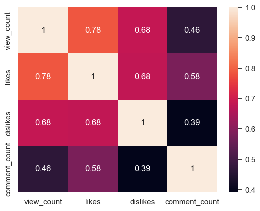

```python
# Show Correlation
sns.heatmap(df.corr(),annot=True)
plt.show()
```

=>People tends to Comment more in likes video rather than dislikes videos

```python
df1=round((pd.pivot_table(df,index="published_month",values="video_id",aggfunc="count")/len(df))*100,2).sort_values(by="video_id",ascending=False)
df2=round((pd.pivot_table(df,index="published_month",values="likes",aggfunc="sum")/df.likes.sum())*100,2).sort_values(by="likes",ascending=False)
df3=round((pd.pivot_table(df,index="published_month",values=["dislikes"],aggfunc="sum")/df.dislikes.sum())*100,2).sort_values(by="dislikes",ascending=False)
merged_df = df1.merge(df2, left_index=True, right_index=True)
merged_df = merged_df.merge(df3, left_index=True, right_index=True)
pd.DataFrame(merged_df)
```

| published_month | video_id | likes | dislikes |
| --- | --- | --- | --- |
| October | 13.35 | 13.83 | 13.03 |
| September | 13.03 | 12.12 | 10.42 |
| November | 12.94 | 10.98 | 9.61 |
| August | 11.41 | 11.50 | 13.53 |
| December | 8.22 | 6.60 | 5.91 |
| July | 6.26 | 7.72 | 7.72 |
| June | 6.19 | 7.49 | 8.13 |
| March | 6.03 | 6.96 | 8.51 |
| February | 5.70 | 4.15 | 3.58 |
| April | 5.69 | 6.63 | 7.42 |
| January | 5.63 | 4.44 | 4.09 |
| May | 5.56 | 7.57 | 8.05 |

```python
def log_df(data):# Function to Log normalization
 for col in data.select_dtypes([int,float]).columns:
  data[col]=np.log1p(data[col])
 return data
```

```python
data=log_df(df)#Apply log transformation  for better visualization of dataset
```

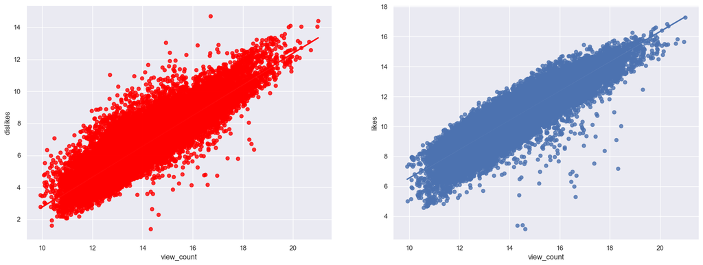

```python
plt.figure(figsize=(20,7))# Show relationship between view_count with like and dislikes
plt.subplot(1,2,1)
sns.regplot(data=data,x="view_count",y="dislikes",color="red",)
plt.subplot(1,2,2)
sns.regplot(data=data,x="view_count",y="likes")
plt.show()
```

=>Both likes and dislikes make positive relation with view_count that indicates which video has more views alse has more likes and dislikes

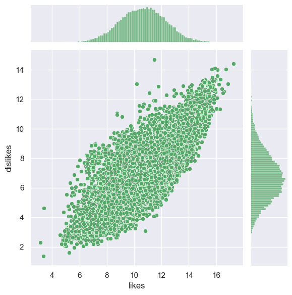

```python
sns.jointplot(data=data,x="likes",y="dislikes",color="g") #Show Distribution and Realation of likes and dislikes
plt.show()
```

=>Videos with a higher number of likes also tend to have a higher number of dislikes, but the number of dislikes is significantly lower in comparison.

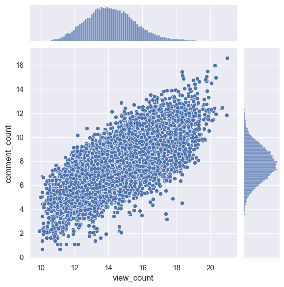

```python
sns.jointplot(data=data,x="view_count",y="comment_count")  #Show Distribution and Realation of view_count and comment_count
plt.show()
```

=>Higher view counts generally result in more comments, but the comments_count is often much lower than the view_count.

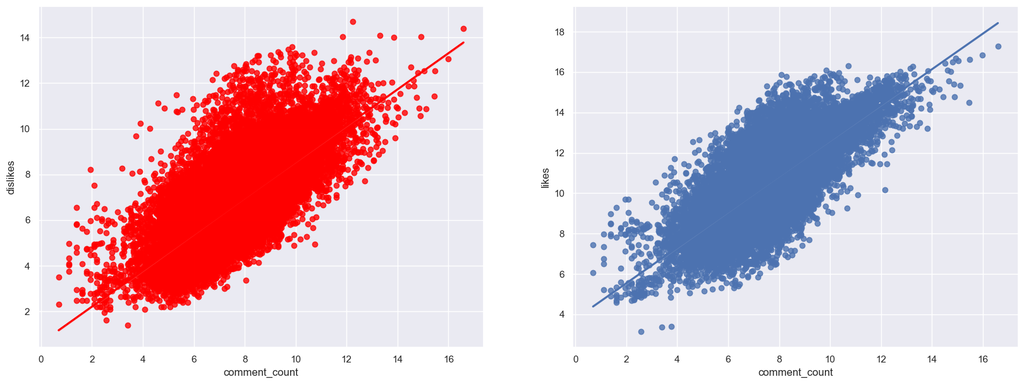

```python
plt.figure(figsize=(20,7))# Show relationship between comment_count with like and dislikes
plt.subplot(1,2,1)
plt.subplot(1,2,1)
sns.regplot(data=data,x="comment_count",y="dislikes",color="red",)
plt.subplot(1,2,2)
sns.regplot(data=data,x="comment_count",y="likes")
plt.show()
```

1. Both likes and dislikes make positive relation with comment_count that indicates which video has more number of likes and dislikes also has more number comments.
2. When people like a video, they tend to comment more compared to when they dislike it.

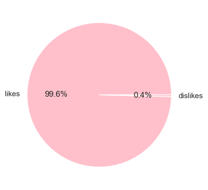

```python
y=[data[data["likes"]>=data["dislikes"]]["video_id"].count(),data[data["likes"]<=data["dislikes"]]["video_id"].count()]
x=["likes","dislikes"]
plt.pie(y,labels=x,autopct="%1.1f%%",colors=['pink'] )
plt.show()
```

=>Only 0.4% video where (Number of dislikes >= Number of likes)

Key Observations and Inferences:

1.The dataset contains information about 37,264 videos, showcasing a diverse range of content available on YouTube.

2. Video metrics (view count, likes, dislikes, and comments) exhibit significant variability, with a few videos has high engagement.

3. The presence of multiple videos with identical titles, channel IDs, and channel titles suggests some content or videos from the same channels.

4. The channel "Sky Sports Football" stands out with 533 videos, indicating popularity of sports-related content on YouTube.

6. Some videos have achieved extraordinary success, such as "BTS () 'Dynamite' Official MV" with an impressive 31,837,675 likes. On the other hand, the video "Cuties | Official Trailer | Netflix" received significant negative feedback, accumulating 2,397,733 dislikes.

7. There is a strong positive correlation (0.78) between view count and likes, suggesting popular videos receive more likes.Similarly, there is a positive correlation (0.68) between view count and dislikes, indicating that highly viewed videos might attract more dislikes as well.

Suggestions and Considerations :

Note = > Considering factors such as (botting, creator and audience ,sentiment and preferences, and the right to speech)for giving better insights and suggestions:

Botting dislikes : refers to the use of automated programs or bots to generate a large number of dislikes on a particular piece of content, such as videos, posts, or comments. This practice can be used to artificially manipulate the perception of audience sentiment and negatively impact the content's reputation.

Hiding dislikes on YouTube is a controversial decision that has both pros and cons.

Pros:

(a). Prevents dislike botting and protects creators from harassment and

(b). Provides creators with more constructive feedback and insights into audience sentiment and preferences

(c). Encourages creators to experiment with new ideas and topics

Cons:

(a). Reduces transparency and accountability of YouTube’s platform

(b). Creates a false impression of popularity or consensus for some videos

(c). Not giving users of their voice and choice

Suggestions :

YouTube should strike a balance between promoting a positive environment and maintaining transparency on its platform. By continuously monitoring and analyzing video engagement metrics, implementing intelligent algorithms, and fostering constructive feedback, YouTube can enhance its user experience and satisfaction, and support its content creators and marketers in creating relevant and engaging content. This analysis enables data-driven decision-making and paves the way for a deeper understanding of user preferences and content trends on YouTube.